# clust_stand_err_final

Jackie

7/21/2021

# 1 libraries

```r
library(tidyverse)
library(lmtest)
library(lubridate)
library(pmdplyr)
library(sandwich)
library(performance)
library(sjPlot)
library(sjstats)
```

## 1.1 functions

```r
getmode <- function(v, na.rm=TRUE) {
   uniqv <- unique(v)
   uniqv[which.max(tabulate(match(v, uniqv)))]
}
# function from ben bolker
mylag <- function(x,lag) {
  c(rep(NA,lag),head(x,-lag))
}
```

# 2 Read in data

## 2.1 Aggregating

In these types of data sampling situations (different frequency of assessment) – the typical solution for examination of coupling seems to be to aggregate to a common time-sampling frame (e.g., day-level) and locate coupling at that timescale.

```r
mw_sleep_fp <- "~/Box/Mooddata_Coordinating/1_Lab_Coordinating/Users/JackieSchwartz/Dissertation/0_MW_Act_Demo_Descriptives/MW_daily_sleep_data_longform.csv"
mw_sleep <- read_csv(mw_sleep_fp) %>%
  mutate(
    ELS_ID = factor(ELS_ID),
    day = factor(day),
    wday = factor(wday),
    dayorder = factor(dayorder),
    week = factor(week),
    trigger_tod = "Morning",
    trigger_tod = factor(trigger_tod)
    ) %>%
  dplyr::select(
    ELS_ID,
    triggerdate,
    day,
    dayorder,
    sleep_trigger_time,
    trigger_tod,
    wday,
    week,
    everything(),
    -Session
  ) %>%
  dplyr::rename(., triggertime = sleep_trigger_time) %>%
  mutate(
    day = factor(day)
  ) %>%
  mutate(
    triggerdate = ymd(triggerdate),
    day = day(triggerdate)
  ) %>%
  group_by(ELS_ID) %>%
  mutate(
    dayorder = order(triggerdate)
    ) %>%
  dplyr::select(
    ELS_ID,
    triggerdate,
    day,
    dayorder,
    trigger_tod,
    starts_with("DailySleep")
  ) %>%
  mutate(
    trigger_tod_order =
      ifelse(
        trigger_tod == "Morning",
        "1",
        NA
        )
    ) %>%
  relocate(trigger_tod_order, .after = trigger_tod) %>%
  mutate(
    trigger_tod_order = as.numeric(trigger_tod_order)
  ) %>%
  group_by(ELS_ID) %>%
  mutate(
    dayorder = as.numeric(dayorder),
    respnumber = dayorder - min(dayorder) + 1
  ) %>%
  filter(dayorder < 15) %>%
  relocate(respnumber , .after = dayorder) %>%
  mutate(
    day_id =  time_variable(triggerdate, .method = "day")
    ) %>%
  relocate(day_id, .after = day) %>%
  filter(day_id < 15) %>%
  dplyr::select(-c(day, dayorder)) # already aggregated by day

mw_sleep_select <-
  mw_sleep %>%
  dplyr::select(-c(day_id, respnumber, DailySleep_hrs))
```

## 2.2 affect: EMA

```r
mw_emo_fp <- "~/Box/Mooddata_Coordinating/1_Lab_Coordinating/Users/JackieSchwartz/Dissertation/2_study2/MW_daily_emo_data_longform.csv"
mw_emo <- read_csv(mw_emo_fp) %>%
  dplyr::select(
    ELS_ID,
    mw_start_date,
    emo_trigger_time,
    emo_trigger_recode,
    triggerdate,
    day,
    wday,
    dayorder,
    day_id,
    neg_total,
    pos_total,
    data_num_obs,
    n_per_tod,
    week
  ) %>%
  rename(
    respnumber = dayorder
  )

mw_emo_filt <-
  mw_emo %>%
  mutate(
    trigger_tod_order =
      ifelse(
        emo_trigger_recode == "Morning",
        "1",
        NA
        ),
    trigger_tod_order =
      ifelse(
        emo_trigger_recode == "Afternoon",
        "2",
        trigger_tod_order
        ),
    trigger_tod_order =
      ifelse(
        emo_trigger_recode == "Evening",
        "3",
        trigger_tod_order
        )
    ) %>%
  relocate(trigger_tod_order, .after = emo_trigger_recode) %>%
  mutate(
    trigger_tod_order = as.numeric(trigger_tod_order),
    iddrop =
      ifelse(
        ELS_ID == "199" &
          str_detect(mw_start_date, "2021-02"),
        "drop",
        NA
      )
  ) %>%
  filter(is.na(iddrop)) %>%
  dplyr::select(-iddrop) %>%
  mutate(
    ELS_ID = factor(ELS_ID)
  )

## reading in RR
emorrfp <- "~/Box/Mooddata_Coordinating/1_Lab_Coordinating/Users/JackieSchwartz/Dissertation/mw_daily_emo_rr.csv"
emorr <-
  read_csv(emorrfp) %>%
  dplyr::select(
    ELS_ID,
    Enrolled,
    Daily_Emotion_Responses,
    emo_resp_rate
  ) %>%
  mutate(
    dup = duplicated(ELS_ID), # 120 (april 2019), 201 (July 2020), 199 (april 2021 - the one with 7 responses)
    drop =
      ifelse(
        ELS_ID == "120" &
          Enrolled == "09-07-2021 10:35:28",
        "drop",
        NA
        ),
    drop =
      ifelse(
        ELS_ID == "201" &
          Enrolled == "Not Enrolled",
        "drop",
        drop
      ),
    drop =
      ifelse(
        ELS_ID == "199" &
          Daily_Emotion_Responses == "31",
        "drop",
        drop
      )
  ) %>%
  filter(is.na(drop)) %>%
  dplyr::select(-drop, -dup) %>%
  mutate(
    ELS_ID = as.numeric(ELS_ID),
    ELS_ID = factor(ELS_ID)
  )

# merging RR with the daily emo df
mw_emo_filt_merge <-
  left_join(
    mw_emo_filt,
    emorr,
    df = "ELS_ID"
  ) %>%
  rename(trigger_tod = emo_trigger_recode) %>%
  mutate(trigger_tod = factor(trigger_tod))
```

```r
mw_icafp <- "~/Box/Mooddata_Coordinating/1_Lab_Coordinating/Users/JackieSchwartz/Dissertation/3_study3/mw_36R_clean_sens.csv"
mw_ica <-
  read_csv(mw_icafp) %>%
  mutate(ELS_ID = factor(ELS_ID))
```

# 3 Merging

```r
# just the EMA stuff
mw_merge <-
  left_join(
    mw_emo_filt_merge,
    mw_sleep_select,
    by = c("ELS_ID", "triggerdate", "trigger_tod", "trigger_tod_order")
  ) %>%
  mutate(
    triggerdate = ymd(triggerdate),
    day = day(triggerdate)
  ) %>%
  group_by(ELS_ID) %>%
  mutate(
    day_id =  time_variable(triggerdate, .method = "day"),
    dayorder = order(triggerdate),
    dayorder = as.numeric(dayorder),
    respnumber = dayorder - min(dayorder) + 0,
    day_id = day_id - min(day_id) + 0,
    trigger_tod_order = trigger_tod_order - min(trigger_tod_order) + 0
    ) %>%
  dplyr::select(
    ELS_ID, triggerdate, day_id, respnumber, trigger_tod, trigger_tod_order, DailySleep_satisfaction, DailySleep_hrs_rec, neg_total, pos_total, emo_resp_rate
  )

mw_merge %>%
  distinct(ELS_ID) # 131
```

```
## # A tibble: 131 x 1
## # Groups:   ELS_ID [131]
##    ELS_ID
##    <fct>
##  1 2
##  2 5
##  3 12
##  4 13
##  5 14
##  6 20
##  7 21
##  8 24
##  9 26
## 10 36
## # … with 121 more rows
```

### 3.0.1 merging with brain data in case I decide to look at this based on my other brain findings

```r
mw_merge <-
  left_join(
    mw_merge,
    mw_ica,
    by = "ELS_ID"
  )
```

## 3.1 MW EMO Start Date

```r
emo_rr_fp <- "~/Box/Mooddata_Coordinating/1_Lab_Coordinating/Users/JackieSchwartz/Dissertation/mw_daily_emo_rr.csv"
emo_rr <-
  read_csv(emo_rr_fp) %>%
  dplyr::select(
    ELS_ID, Identifier, Enrolled, emo_resp_rate
  ) %>%
  rename(User_ID = Identifier) %>%
  mutate(
    ELS_ID = as.numeric(ELS_ID),
    ELS_ID = factor(ELS_ID),
    dup = duplicated(User_ID)
  )  %>% # keeping ELS_ID 201 and 199 with april enrolled date
mutate(
    drop =
      ifelse(
        ELS_ID == "201" &
          Enrolled == "Not Enrolled",
        "drop",
        NA
        )
  ) %>%
  filter(is.na(drop)) %>%
  dplyr::select(ELS_ID, emo_resp_rate)
```

# 4 Reading in pubertal and demo data

> the suffix "_mw" or "_act" indicates whether that Tanner assessemnt was administered closer to the actigraphy or EMA data. 154 participants had usable actigraphy or EMA data; however, 6 participants were excluded based on being in early puberty (Tanner stage < 3), bringing our total to 148 participants. 136 had usable actigraphy data and 111 had usable EMA data via Metricwire data. 54% of our sample (N=80) completed actigraphy and EMA components simultaneously (overlapping at least 7 days). This was not by design, but because of participant scheduling/contacting issues or bc of participant issues, the other half of the participants either completed both components several months apart from each other, *or* they completed only one of the componets (either EMA *or* actigraphy due to various reasons (e.g., didn’t want to wear a watch, didn’t want the app on their phones, data from one component wasn’t usable, etc…)). To include as many participants as possible in our analyses (to increase generalizability and statistical power), we conducted the EMA and actigraphy analyses separately.

```r
# full AHC sample with pubertal and demographic info
pub_demo_act_mw_comb_fp <- "~/Box/Mooddata_Coordinating/1_Lab_Coordinating/Users/JackieSchwartz/Dissertation/0_MW_Act_Demo_Descriptives/dem_and_tanner_mw_act_comb_merge.csv"
pub_demo <-
  read_csv(pub_demo_act_mw_comb_fp) %>%
  mutate(ELS_ID = factor(ELS_ID))%>%
  dplyr::select(
    ELS_ID,
    SIMUL_AHC,
    tanner_date_for_act,
    tanner_date_for_mw,
    tanner_average_for_act,
    tanner_average_for_mw,
    tanner_adrenal_act,
    tanner_adrenal_mw,
    tanner_gonadal_act,
    tanner_gonadal_mw,
    tanner_age_for_act,
    tanner_age_for_mw,
    COVID_AHC_MW,
    COVID_AHC_ACT,
    Sex,
    BMI_MW,
    BMI_ACT,
    Household_Income_MW,
    Household_Income_ACT,
    SIMUL_AHC,
    cmep_total_mw,
    cmep_total_act,
    sumsev_type
  )

hormonedatafp <- "~/Box/Mooddata_Coordinating/1_Lab_Coordinating/Users/JackieSchwartz/Dissertation/1_study1/pub_mw_hormones_clean.csv"
hormonedata <-
  read_csv(hormonedatafp) %>%
  dplyr::select(
    ELS_ID,
    ends_with("_clean")
  ) %>%
  mutate(ELS_ID = factor(ELS_ID))

asqfp <- "~/Box/Mooddata_Coordinating/1_Lab_Coordinating/Users/JackieSchwartz/Dissertation/2_study2/asqmw.csv"
asq <-
  read_csv(asqfp) %>%
  mutate(ELS_ID = factor(ELS_ID))
```

## 4.1 merging with EMA data

```r
mw_merge_order_dem_all <-
  left_join(
    mw_merge,
    pub_demo,
    by = "ELS_ID"
  )

mw_merge_order_dem_all <-
  left_join(
    mw_merge_order_dem_all,
    hormonedata,
    by = "ELS_ID"
  )

mw_merge_order_dem_all <-
  left_join(
    mw_merge_order_dem_all,
    asq,
    by = "ELS_ID"
  ) %>%
  drop_na(tanner_average_for_mw)
```

# 5 Summary

```r
mw_merge_sum_ema <-
  mw_merge_order_dem_all %>%
  distinct(ELS_ID)
# 106 IDs have EMA data (sleep + affect);

mw_merge_order_dem_all%>%
  group_by(ELS_ID) %>%
  summarize(
    daymax = length(day_id)
  )
```

```
## # A tibble: 106 x 2
##    ELS_ID daymax
##    <fct>   <int>
##  1 2          16
##  2 5          28
##  3 6          39
##  4 13         12
##  5 14         25
##  6 16         37
##  7 17         42
##  8 20         25
##  9 21         15
## 10 22         39
## # … with 96 more rows
```

```r
mw_merge_order_dem_all2 <-
  mw_merge_order_dem_all %>%
  group_by(ELS_ID) %>%
  mutate(
    daymax = length(day_id),
    toofewdays =
      ifelse(
        daymax < 3, # dropping fewer than 3 days of observations
        "drop",
        NA
        )
    ) %>%
  filter(
    is.na(toofewdays)
  ) %>%
  dplyr::select(-daymax, -toofewdays)

mw_merge_order_dem_all2 %>%
  group_by(ELS_ID) %>%
  summarize(
    daymax = length(day_id)
  )
```

```
## # A tibble: 106 x 2
##    ELS_ID daymax
##    <fct>   <int>
##  1 2          16
##  2 5          28
##  3 6          39
##  4 13         12
##  5 14         25
##  6 16         37
##  7 17         42
##  8 20         25
##  9 21         15
## 10 22         39
## # … with 96 more rows
```

```r
# 106 participants have 3 or more days of sleep and affect data
```

```r
summary(as.integer(table(mw_merge_order_dem_all2$ELS_ID))) # els ids subj
```

```
##    Min. 1st Qu.  Median    Mean 3rd Qu.    Max.
##    0.00    0.00   20.00   18.66   34.00   44.00
```

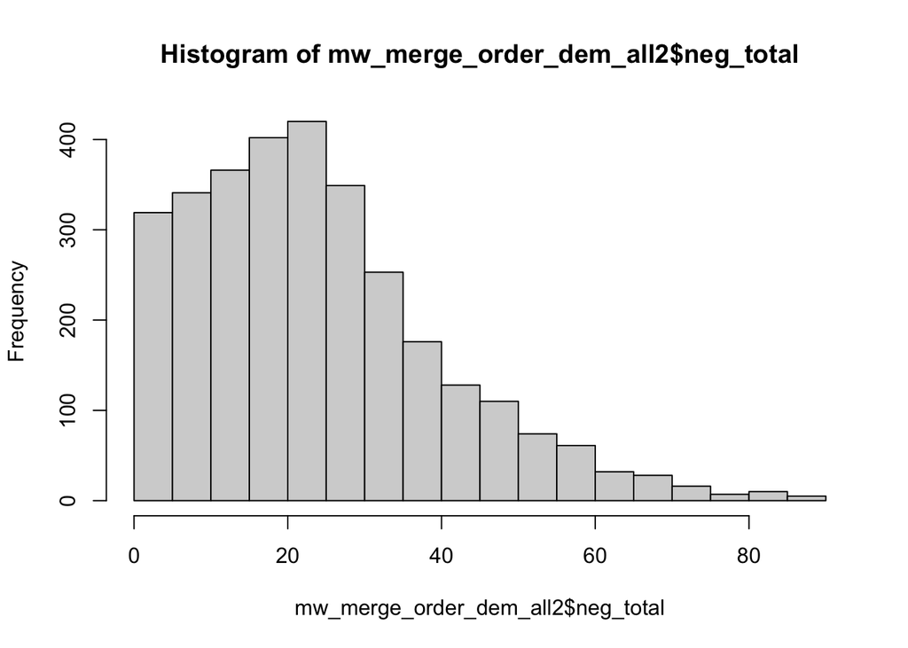

```r
hist(mw_merge_order_dem_all2$neg_total)
```

```r
library(moments)

skewness(mw_merge_order_dem_all2$neg_total) # 0.9293557
```

```
## [1] 0.9293557
```

```r
mw_merge_order_dem_all2 <-
  mw_merge_order_dem_all2 %>%
  mutate(
    neg_total_log = log10(neg_total),
    neg_total_sqrt = sqrt(neg_total)
  )
skewness(mw_merge_order_dem_all2$neg_total_log) # -1.301284 ooo terrible
```

```
## [1] -1.301284
```

```r
skewness(mw_merge_order_dem_all2$neg_total_sqrt) # -0.04143427 much better
```

```
## [1] -0.04143427
```

```r
summary(mw_merge_order_dem_all2$neg_total_sqrt)
```

```
##    Min. 1st Qu.  Median    Mean 3rd Qu.    Max.
##   1.000   3.423   4.598   4.554   5.686   9.373
```

```r
mean(mw_merge_order_dem_all2$neg_total_sqrt)
```

```
## [1] 4.554283
```

```r
sd(mw_merge_order_dem_all2$neg_total_sqrt)
```

```
## [1] 1.734913
```

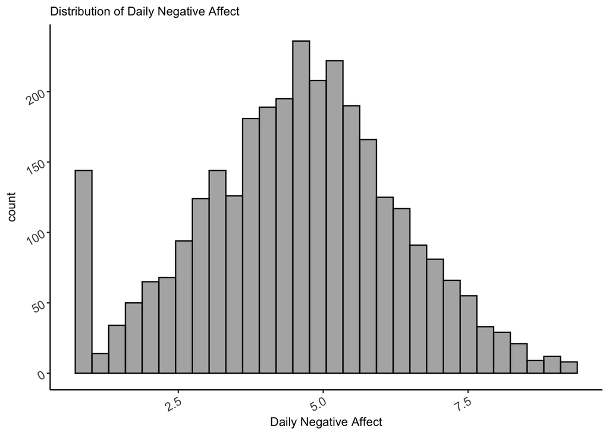

```r
neg_total_sqrt_hist <-
  mw_merge_order_dem_all2 %>%
  ggplot(
    aes(x = neg_total_sqrt)
  ) +
  geom_histogram(color = "black", alpha = .5) +
  theme_classic() +
  labs(
    x = "Daily Negative Affect",
    title = "Distribution of Daily Negative Affect"
  ) +
  theme(
    axis.text = element_text(size = 10, angle = 30, hjust = 1),
    axis.title = element_text(size = 10),
    plot.title = element_text(size = 10)
  )
neg_total_sqrt_hist
```

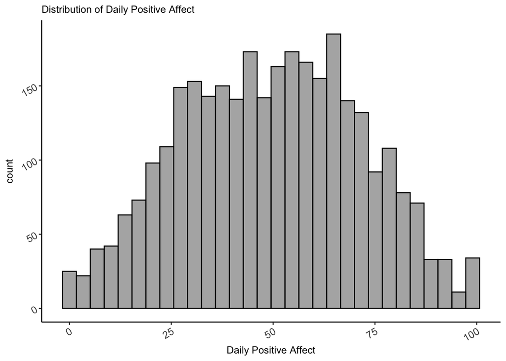

```r
pos_total_sqrt_hist <-
  mw_merge_order_dem_all2 %>%
  ggplot(
    aes(x = pos_total)
  ) +
  geom_histogram(color = "black", alpha = .5) +
  theme_classic() +
  labs(
    x = "Daily Positive Affect",
    title = "Distribution of Daily Positive Affect"
  ) +
  theme(
    axis.text = element_text(size = 10, angle = 30, hjust = 1),
    axis.title = element_text(size = 10),
    plot.title = element_text(size = 10)
  )
pos_total_sqrt_hist
```

```r
library(gridExtra)
```

```r
library(cowplot)
pana_dist <-
  cowplot::plot_grid(
    neg_total_sqrt_hist,
    pos_total_sqrt_hist,
    labels = c('A', 'B'),
    label_size = 10
    )
ggsave("pana_dist.png", pana_dist, width = 7, height = 3.5)
```

## 5.1 how many clusters do we have?

```r
sumclust <-
  mw_merge_order_dem_all2 %>%
  distinct(ELS_ID)
```

# 6 Option 1: the sandwich package

The `sandwich` package implements several methods for robust covariance estimators, including clustered SEs. Details are explained in **Zeileis et al. 2020**. The accompanying `lmtest` package provides functions for coefficient tests that take into account the calculated robust covariance estimates.

As explained initially, the parameter estimates from our model are fine despite the clustered structure of our data. But the SEs are likely biased downward and need to be corrected.

1. We need to use `coeftest` from the `lmtest` package;
2. we need to pass it our model and either a function to calculate the covariance matrix or an already estimated covariance matrix to the `vcov` parameter;
3. we need to specify a cluster variable in the cluster parameter.

The `sandwich` package provides several functions for estimating robust covariance matrices. We need `vcovCL` for clustered covariance estimation and will pass this function as vcov parameter. Furthermore, we cluster by subject ID, so the cluster variable is ELS_ID # Clustered Robust Standard Errors (CR-SE)

## 6.1 showing clusters of ELS_IDs in relation to neg affect

```r
mw_merge_cent <-
  mw_merge_order_dem_all2 %>%
  dplyr::select(
    -c(ends_with("_act"), ends_with("_ACT"))
  ) %>%
  mutate(
    Sex = factor(Sex),
    COVID_AHC_MW = factor(COVID_AHC_MW),
    sumsev_type_z = scale(sumsev_type),
    dhea_clean_z = scale(dhea_clean),
    cort_clean_z = scale(cort_clean),
    test_clean_z = scale(test_clean),
    cmep_total_mw_z = scale(cmep_total_mw),
    asq_total_mw_z = scale(asq_total_mw)
    ) %>%
  group_by(Sex) %>%
  mutate(
    tanner_average_for_mw_z = scale(tanner_average_for_mw), # standardizing tanner average within each sex
    tanner_adrenal_mw_z = scale(tanner_adrenal_mw), # standardizing tanner adrenal within each sex
    tanner_gonadal_mw_z = scale(tanner_gonadal_mw), # standardizing tnaner gonadal within each sex
    bmi_at_mw_z = scale(BMI_MW), # standardizing bmi within each sex
    tanner_age_for_mw_z = scale(tanner_age_for_mw) # standardizing age within each sex
  ) %>%
  ungroup()

library(lmerTest)
```

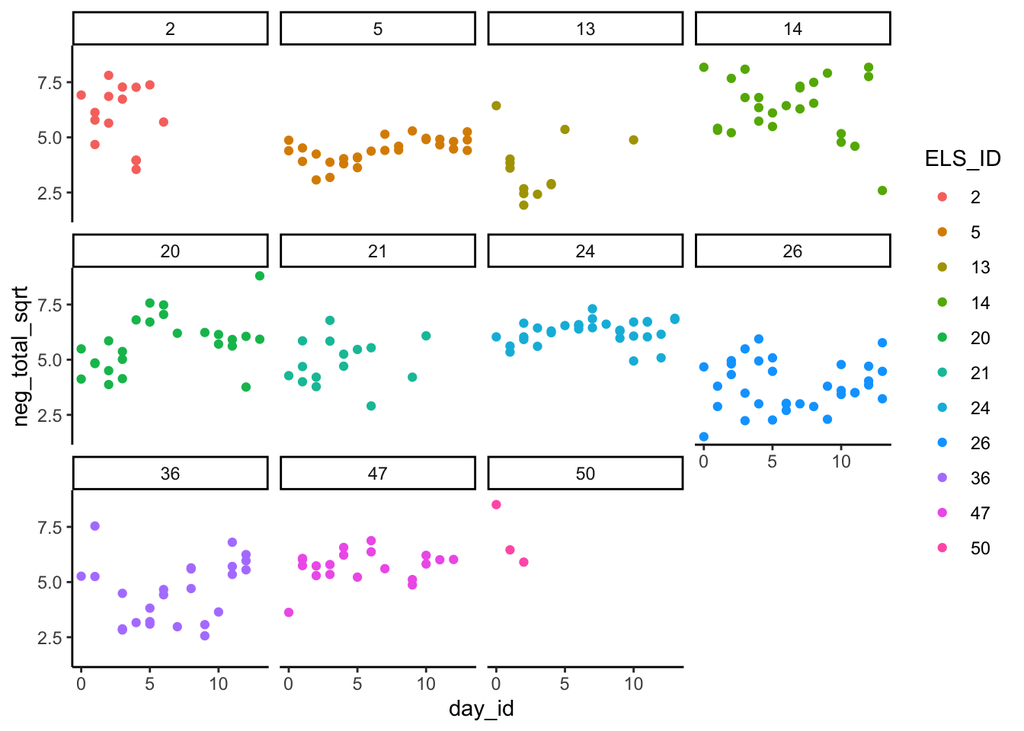

```r
mw_merge_cent_randids <-
  mw_merge_cent[1:234,]
mw_merge_cent_randids %>%
  ggplot(
    aes(
      x = day_id,
      y = neg_total_sqrt,
      color = ELS_ID
    )
  ) +
  geom_point()+
  facet_wrap(~ELS_ID) +
  theme_classic()
```

```r
library(misty)
multilevel.icc(mw_merge_cent$neg_total_sqrt, group = mw_merge_cent$ELS_ID, type = 1, method = "lme4") # 0.6100043
```

```
## [1] 0.6100043
```

```r
mod <- lmer(neg_total_sqrt ~ 1 + (1|ELS_ID), data = mw_merge_cent)
icc(mod)
```

```
## # Intraclass Correlation Coefficient
##
##      Adjusted ICC: 0.610
##   Conditional ICC: 0.610
```

```r
multilevel.icc(mw_merge_cent$pos_total, group = mw_merge_cent$ELS_ID, type = 1, method = "lme4") # 0.4910874
```

```
## [1] 0.4910874
```

```r
multilevel.icc(mw_merge_cent$DailySleep_satisfaction, group = mw_merge_cent$ELS_ID, type = 1, method = "lme4") # 0.4152467
```

```
## [1] 0.4152467
```